# Гетероскедастичность в простой регрессии

> Одним из нарушений условий ТГМ является гетероскедастичность, возникающая ввиду неодинаковых дисперсий для разных наблюдений. Она нежелательна ввиду того, что оценки МНК не являются эффективными (но остаются несмещёнными), и предпосылки для использования `t`-статистик нарушены, что даёт неверный результат о значимости коэффициентов.

Этот коан благословит Вас на поиски гетероскедастичности и просветит о способах борьбы с ней.

Будем анализировать гетероскедастичность на данных о стоимости квартир.

## r

Вызовем **r** в помощь в охоте на гетероскедастичность. Импортируем его оружейные пакеты.

```r
library(rio) # импорт и экспорт данных в разных форматах
library(dplyr) # манипуляции с данными
library(lmtest) # тест Бройша-Пагана
library(sandwich) # оценка дисперсии при гетероскедастичности
library(UStatBookABSC) # WLS
library (estimatr) # получение робастных оценок
library(ggpubr) # для графиков
library(skimr) # для описательных статистик
```

Импортируем наш dataset, `flats.dta`:

```r
flats= import("data/flats.dta")
```

Рассмотрим описательные статистики загруженного датасета.

```r
skim(flats)
```

```
Skim summary statistics
 n obs: 773
 n variables: 44

-- Variable type:character -------------------------------------
                   variable missing complete   n min max empty n_unique
                      okrug       0      773 773   0   4     1        4
 sanuzel__1_razdel__0_sovm_       0      773 773   1   2     0        3

-- Variable type:numeric ---------------------------------------
         variable missing complete   n        mean         sd         p0
              bal       0      773 773       0.53        0.5        0
            brick       0      773 773       0.16        0.37       0
             dist       0      773 773      12.19        4.66       5
            floor       0      773 773       0.83        0.38       0
           floor1       0      773 773       0.097       0.3        0
           floor2       0      773 773       0.074       0.26       0
           floors       0      773 773      15.71        9.09       3
            kitsp       0      773 773       8.09        2.85       2
           livesp       0      773 773      21.45        7.25       8
          ln_dist       0      773 773       2.43        0.4        1.61
       ln_dist_sq       0      773 773       6.04        1.88       2.59
        ln_floors       0      773 773       2.59        0.59       1.1
     ln_floors_sq       0      773 773       7.05        3.03       1.21
         ln_kitsp       0      773 773       2.02        0.41       0.69
      ln_kitsp_sq       0      773 773       4.24        1.48       0.48
        ln_livesp       0      773 773       3.02        0.27       2.08
     ln_livesp_sq       0      773 773       9.22        1.74       4.32
      ln_metrdist       0      773 773       2.04        0.55       0
   ln_metrdist_sq       0      773 773       4.49        2.07       0
 ln_metrdist_walk       0      773 773       0.97        1.09       0
        ln_nfloor       0      773 773       1.7         0.89       0
     ln_nfloor_sq       0      773 773       3.69        3.04       0
   ln_price_meter       0      773 773      12.19        0.3       11.35
    ln_price_metr       0      773 773      12.19        0.3       11.35
         ln_totsp       0      773 773       3.6         0.28       2.71
      ln_totsp_sq       0      773 773      13.01        1.94       7.33
        ln_totsp2       0      773 773      13.01        1.94       7.33
        ln_totsp3       0      773 773      28.34        8.55       8.99
         metrdist       0      773 773       8.83        4.44       1
```

[output cut: 41 more lines]

```
      24.15      25.53      28.22    72.74    ▁▃▇▁▁▁▁▁
       5         10         10       40       ▅▇▃▁▁▁▁▁
     196        397        595      788       ▇▇▇▇▇▇▇▇
       0          0          1        1       ▇▁▁▁▁▁▁▃
       3          6         11      127       ▇▁▁▁▁▁▁▁
       5          8         11       25       ▅▅▇▇▂▁▁▁
       0          0          1        1       ▇▁▁▁▁▁▁▆
 5750000    6700000    8600000        1.8e+07 ▁▇▃▂▂▁▁▁
  167187.5   189393.9   223076.9  6e+05       ▂▇▂▁▁▁▁▁
       1          1          1        1       ▁▁▁▇▁▁▁▁
       0          0          1        1       ▇▁▁▁▁▁▁▅
       1          1          1        3       ▁▁▇▁▁▁▁▁
      32         38         42       75       ▂▁▇▇▂▂▁▁
       0          0          0        1       ▇▁▁▁▁▁▁▂
       0          0          1        1       ▇▁▁▁▁▁▁▇
```

Построим простую линейную регрессионную модель, на которой будем проверять гетероскедастичность.

```r
reg = lm(ln_price_metr ~ 1 + ln_livesp + ln_kitsp + ln_dist + ln_metrdist, data = flats)
summary(reg)
```

```
Call:
lm(formula = ln_price_metr ~ 1 + ln_livesp + ln_kitsp + ln_dist +
    ln_metrdist, data = flats)

Residuals:
     Min       1Q   Median       3Q      Max
-0.62723 -0.16125 -0.00845  0.13614  0.77618

Coefficients:
            Estimate Std. Error t value Pr(>|t|)
(Intercept) 14.19920    0.13492 105.243  < 2e-16 ***
ln_livesp   -0.16053    0.03723  -4.312 1.83e-05 ***
ln_kitsp    -0.29913    0.02300 -13.007  < 2e-16 ***
ln_dist     -0.33025    0.02367 -13.952  < 2e-16 ***
ln_metrdist -0.05738    0.01560  -3.679 0.000251 ***
---
Signif. codes:  0 '***' 0.001 '**' 0.01 '*' 0.05 '.' 0.1 ' ' 1

Residual standard error: 0.2309 on 768 degrees of freedom
Multiple R-squared:  0.4179,    Adjusted R-squared:  0.4149
F-statistic: 137.9 on 4 and 768 DF,  p-value: < 2.2e-16
```

Проверим наличие гетероскедастичности визуально. Построим зависимости цены квартир от объясняющих факторов.

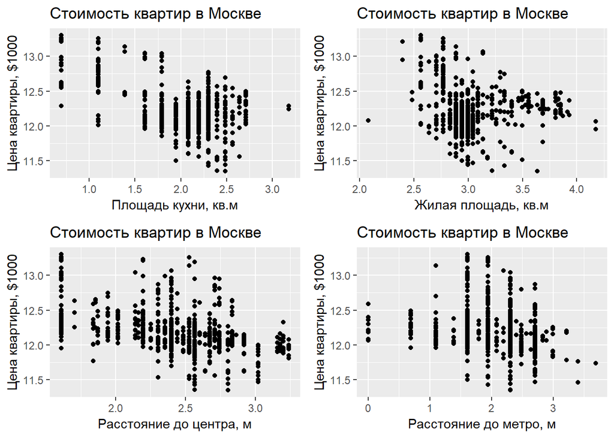

```r
kit = ggplot(flats) + geom_point(aes(x = ln_kitsp, y = ln_price_metr)) +
  labs(x = "Площадь кухни, кв.м", y = "Цена квартиры, $1000",
  title = "Стоимость квартир в Москве")
live = ggplot(flats) + geom_point(aes(x = ln_livesp, y = ln_price_metr)) +
  labs(x = "Жилая площадь, кв.м", y = "Цена квартиры, $1000",
  title = "Стоимость квартир в Москве")
dist = ggplot(flats) + geom_point(aes(x = ln_dist, y = ln_price_metr)) +
  labs(x = "Расстояние до центра, м", y = "Цена квартиры, $1000",
  title = "Стоимость квартир в Москве")
metrdist = ggplot(flats) + geom_point(aes(x = ln_metrdist, y = ln_price_metr)) +
  labs(x = "Расстояние до метро, м", y = "Цена квартиры, $1000",
  title = "Стоимость квартир в Москве")

ggarrange(kit, live, dist, metrdist, ncol = 2, nrow = 2)
```

Из сета красивых графиков видно, что гетероскедастичность присутствует. В частности, подозрительны переменные `ln_kitsp` и `ln_metrdist`.

Проверим наличие гетероскедастичности с помощью тестов. Начнём с теста Уайта. Он неконструктивный, он может лишь показать наличие гетероскедастичности, асимптотический. Нормальность остатков в предпосылках не требуется, подразумевается, что
$$E{\varepsilon^4_i} = const$$
.

$$\begin{cases}
H_0: \sigma^2_i = \sigma^2 \\
H_1: \sigma^2_i \neq = \sigma^2 \\
\end{cases}$$

На первом шаге тест сохраняет остатки от построения начальной регрессии.
$$\hat{\ln{(pricemetr_i)}} = \hat{\beta}_0 + \hat{\beta}_{\ln{(kitsp)}} \cdot \ln{(kitsp_i)} + \hat{\beta}_{\ln{(livesp)}}\cdot \ln{(livesp_i)} + \hat{\beta}_{\ln{(dist)}}\cdot \ln{(dist_i)} + \hat{\beta}_{\ln{(metrdist)}}\cdot \ln{(metrdist_i)}$$
На втором - строится вспомогательная регрессия (X_j-вектор j-го фактора).
$$\hat{e}^2_i = \hat{\alpha}_0 + \sum_{j=1}^{k} \hat{\alpha}_j \cdot X_j + \sum_{j=1}^{k} \hat{\gamma}_j \cdot X^2_j + \sum_{j < m}^{k} \hat{\delta}_j X_j \cdot X_m$$

`R-squared` построенной вспомогательной регрессии должен быть распределён как:
$$n \cdot R^2_{aux} \sim \chi^2_{K-1}$$
где `K` – число факторов во вспомогательной регрессии.

Тест Уайта реализуется (ручками) как:

```r
bptest(reg, varformula = ~ 1 + ln_livesp + ln_kitsp + ln_dist + ln_metrdist + I(ln_livesp ^ 2) + I(ln_kitsp ^ 2) + I(ln_dist ^ 2) + I(ln_metrdist ^ 2) + I(ln_livesp * ln_kitsp) + I(ln_livesp * ln_dist) + I(ln_livesp * ln_metrdist) + I(ln_kitsp * ln_dist) + I(ln_kitsp * ln_metrdist) + I(ln_dist * ln_metrdist), data = flats)
```

```
    studentized Breusch-Pagan test

data:  reg
BP = 89.02, df = 14, p-value = 5.81e-13
```

Тест Уайта выявил гетероскедастичность.

Тест Бройша-Пагана – обобщённый вариант теста Уайта. В тесте Бройша-Пагана во вспомогательной регрессии можно брать любые функции от регрессоров, в тесте Уайта - регрессоры, их квадраты и кросс-произведения. Тест Бройша-Пагана является асимптотическим.

$$\begin{cases}
H_0: \sigma^2_i = \sigma^2 \\
H_1: \sigma^2_i \propto f(\alpha_0 + \alpha_1 \cdot Z_1 + \ldots + \alpha_p \cdot Z_p) \\
\end{cases}$$

Классическая версия Бройша-Пагана строится на основе метода максимального правдоподобия. Предпосылками классической версии теста являются нормальность остатков, существование у функции дисперсии из альтернативной гипотезы первой и второй производной. Считается LM-статистика, которая, при верной основной гипотезе об отсутствии гетероскедастичности, имеет хи-квадратное распределение с p-1 степенью свободы.

Классическая версия Бройша-Пагана реализуется в **r** по команде:

```r
bptest(reg, studentize = FALSE)
```

```
    Breusch-Pagan test

data:  reg
BP = 18.39, df = 4, p-value = 0.001035
```

Современная модификация теста не требует нормальности остатков, лишь
$${\mathbb E}({\varepsilon^4_i}) = const$$
. На первом шаге строится исходная регрессия и сохраняются остатки. Затем строится состоятельная оценка дисперсии:
$$\hat{\sigma}^2 = \frac{1}{n} \cdot \sum_{i=1}^{n} {e^2_i}$$
Потом строится вспомогательная регрессия:
$$\frac{e^2}{\hat{\sigma}^2} = \alpha_0 + \alpha_1 \cdot Z_1 + \ldots + \alpha_p \cdot Z_p + u$$
И рассчитывается тестовая статистика:
$$\frac{RSS_{aux}}{2} \sim \chi^2_{p}$$
Модифицированная версия теста Бройша-Пагана реализуется по команде:

```r
bptest(reg)
```

```
    studentized Breusch-Pagan test

data:  reg
BP = 15.778, df = 4, p-value = 0.003332
```

Причем, если отдельно не указать спецификацию вспомогательной регрессии, то `bptest()` возьмёт все регрессоры исходной модели.

В обеих версиях теста Бройша-Пагана гетероскедастичность обнаружена.

Ещё есть тест Голдфелда-Квандта.

$$\begin{cases}
H_0: \sigma^2_i = \sigma^2 \\
H_1: \sigma^2_i \propto X_i \\
\end{cases}$$

Этот тест предполагает нормальность остатков и является неасимптотическим.

Процедура:

Сначала все наблюдения сортируются по возрастанию абсолютного значения фактора, вызывающего гетероскедастичность.

Затем отсортированный ряд по фактору делится на 3 примерно равные части. Считаются гетероскедастичности по первой и третьей части ряда. Строится `F`-статистика:
$$\frac{RSS_2}{RSS_1} \sim F_{r - k, r-k}$$

где `r` - размер первой и третьей частей отсортированного ряда.

Данный тест в **r** реализуется по командам (предполагается, что дисперсии пропорциональны переменной `ln_kitsp`):

```r
flats_ordered = flats[order(flats$ln_kitsp), ]
reg_gqtest = lm(ln_price_metr ~ 1 + ln_livesp + ln_kitsp + ln_dist + ln_metrdist, data = flats_ordered)
gqtest(reg_gqtest, fraction = 0.34) # посередине отсортированного ряда лежит 34% наблюдений
```

```
    Goldfeld-Quandt test

data:  reg_gqtest
GQ = 1.1072, df1 = 251, df2 = 250, p-value = 0.2106
alternative hypothesis: variance increases from segment 1 to 2
```

Будет также полезным познакомиться с методами борьбы с гетероскедастичностью.

В **r** это можно сделать так:

```r
reg_wls = lm(ln_price_metr ~ 1 + ln_livesp + ln_kitsp + ln_dist + ln_metrdist, data = flats, weights = 1 / (1 / fitted(lm(abs(residuals(reg)) ~ ln_kitsp)) ^ 2))
summary(reg_wls)
```

```
Call:
lm(formula = ln_price_metr ~ 1 + ln_livesp + ln_kitsp + ln_dist +
    ln_metrdist, data = flats, weights = 1/(1/fitted(lm(abs(residuals(reg)) ~
    ln_kitsp))^2))

Weighted Residuals:
      Min        1Q    Median        3Q       Max
-0.105299 -0.029659 -0.001107  0.025053  0.155867

Coefficients:
            Estimate Std. Error t value Pr(>|t|)
(Intercept) 14.28313    0.13557 105.357  < 2e-16 ***
ln_livesp   -0.16102    0.03849  -4.183  3.2e-05 ***
ln_kitsp    -0.33901    0.02245 -15.098  < 2e-16 ***
ln_dist     -0.33075    0.02406 -13.749  < 2e-16 ***
ln_metrdist -0.05859    0.01587  -3.691 0.000239 ***
---
Signif. codes:  0 '***' 0.001 '**' 0.01 '*' 0.05 '.' 0.1 ' ' 1

Residual standard error: 0.04242 on 768 degrees of freedom
Multiple R-squared:  0.4683,    Adjusted R-squared:  0.4655
F-statistic: 169.1 on 4 and 768 DF,  p-value: < 2.2e-16
```

Способ 2. Робастные оценки Уайта.

```r
coeftest(reg, vcov = vcovHC(reg, "HC0"))
```

```
t test of coefficients:

             Estimate Std. Error  t value  Pr(>|t|)
(Intercept) 14.199195   0.158790  89.4210 < 2.2e-16 ***
ln_livesp   -0.160528   0.040845  -3.9302 9.253e-05 ***
ln_kitsp    -0.299130   0.028398 -10.5336 < 2.2e-16 ***
ln_dist     -0.330251   0.023965 -13.7803 < 2.2e-16 ***
ln_metrdist -0.057375   0.014528  -3.9494 8.555e-05 ***
---
Signif. codes:  0 '***' 0.001 '**' 0.01 '*' 0.05 '.' 0.1 ' ' 1
```

Робастные оценки коэффициентов регрессии получаются состоятельными.

## python

Теперь попробуем проделать эти шаги в **python**.

Импотируем необходимые пакеты.

```python
import numpy as np
import pandas as pd # чтение файлов
import matplotlib.pyplot as plt # построение графиков
import seaborn as sns # построение графиков
import statsmodels.api as sm # тесты
from statsmodels.formula.api import ols, WLS # построение регрессии
import statsmodels
import statsmodels.stats.diagnostic as sm_diagnostic # тест Бройша-Пагана
```

Загрузим исследуемый датасет.

```python
flats = pd.read_stata("data/flats.dta")
```

Построим линейную регрессионную модель.

```python
reg = ols("ln_price_metr ~ 1 + ln_livesp + ln_kitsp + ln_dist + ln_metrdist", flats).fit()
reg.summary()
```

```
<class 'statsmodels.iolib.summary.Summary'>
"""
                            OLS Regression Results
==============================================================================
Dep. Variable:          ln_price_metr   R-squared:                       0.418
Model:                            OLS   Adj. R-squared:                  0.415
Method:                 Least Squares   F-statistic:                     137.9
Date:                Thu, 16 Jan 2020   Prob (F-statistic):           9.06e-89
Time:                        17:02:49   Log-Likelihood:                 38.744
No. Observations:                 773   AIC:                            -67.49
Df Residuals:                     768   BIC:                            -44.24
Df Model:                           4
Covariance Type:            nonrobust
===============================================================================
                  coef    std err          t      P>|t|      [0.025      0.975]
-------------------------------------------------------------------------------
Intercept      14.1992      0.135    105.243      0.000      13.934      14.464
ln_livesp      -0.1605      0.037     -4.312      0.000      -0.234      -0.087
ln_kitsp       -0.2991      0.023    -13.007      0.000      -0.344      -0.254
ln_dist        -0.3303      0.024    -13.952      0.000      -0.377      -0.284
ln_metrdist    -0.0574      0.016     -3.679      0.000      -0.088      -0.027
==============================================================================
Omnibus:                       25.080   Durbin-Watson:                   1.309
Prob(Omnibus):                  0.000   Jarque-Bera (JB):               26.855
Skew:                           0.425   Prob(JB):                     1.47e-06
Kurtosis:                       3.331   Cond. No.                         83.2
==============================================================================

Warnings:
[1] Standard Errors assume that the covariance matrix of the errors is correctly specified.
"""
```

Визуализируем зависимости регрессоров и регрессанта.

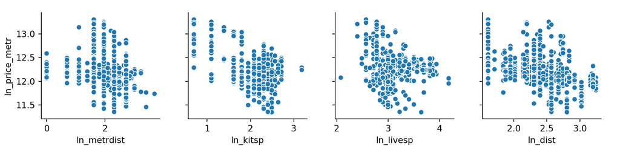

```python
sns.pairplot(flats, x_vars=["ln_metrdist", "ln_kitsp", "ln_livesp", "ln_dist"], y_vars=["ln_price_metr"])
plt.show()
```

Графики всё такие же красивые, как и в предыдущем пункте:) Подозрительны переменные `ln_kitsp` и `ln_metrdist` Проведём тесты на выявление гетероскедастичности в **python**.

Рассмотрим тест Бройша-Пагана на всех факторах.

```python
resid = reg.resid
X = flats[["ln_livesp", "ln_kitsp", "ln_dist", "ln_metrdist"]]
sm_diagnostic.het_breuschpagan(resid=resid, exog_het=X)
```

```
(242.3887600398202, 2.8968538726873906e-52, 87.82180928009087, 1.8044481939655893e-61)
```

Интерпретация результатов теста:

Первое из выданных значений - значение тестовой статистики теста Бройша-Пагана, второе - значение p-value для выданной тестовой статистики. Третье и четвёртое - значения тестовой статистики и её p-value для на уровне значимости 5% (табличное). Гетероскедастичность присутствует.

```python
sm_diagnostic.het_goldfeldquandt(y=flats["ln_price_metr"], x=X, alternative="two-sided")
```

```
(0.5313881847525856, 8.826860679745173e-10, 'two-sided')
```

Значение p-value близко к 0, следовательно, основная гипотеза о гомоскедастичности отвергается.

Теперь о способах борьбы с гетероскедастичностью.

Способ 1. Взвешенный МНК.

Взвешиваем по стандартному отклонению фактора `ln_kitsp`.

```python
reg_wls = statsmodels.regression.linear_model.WLS(flats["ln_price_metr"], X, weights=flats["ln_kitsp"])
reg_wls_results = reg_wls.fit()
reg_wls_results.summary()
```

```
<class 'statsmodels.iolib.summary.Summary'>
"""
                            WLS Regression Results
==============================================================================
Dep. Variable:          ln_price_metr   R-squared:                       0.995
Model:                            WLS   Adj. R-squared:                  0.995
Method:                 Least Squares   F-statistic:                 3.763e+04
Date:                Thu, 16 Jan 2020   Prob (F-statistic):               0.00
Time:                        17:02:52   Log-Likelihood:                -997.20
No. Observations:                 773   AIC:                             2002.
Df Residuals:                     769   BIC:                             2021.
Df Model:                           4
Covariance Type:            nonrobust
===============================================================================
                  coef    std err          t      P>|t|      [0.025      0.975]
-------------------------------------------------------------------------------
ln_livesp       2.9582      0.071     41.469      0.000       2.818       3.098
ln_kitsp       -0.1256      0.095     -1.316      0.189      -0.313       0.062
ln_dist         1.1813      0.068     17.317      0.000       1.047       1.315
ln_metrdist     0.2429      0.057      4.259      0.000       0.131       0.355
==============================================================================
Omnibus:                       13.564   Durbin-Watson:                   1.132
Prob(Omnibus):                  0.001   Jarque-Bera (JB):               23.475
Skew:                          -0.050   Prob(JB):                     7.99e-06
Kurtosis:                       3.848   Cond. No.                         17.4
==============================================================================

Warnings:
[1] Standard Errors assume that the covariance matrix of the errors is correctly specified.
"""
```

Способ 2. Использование робастных оценок.

```python
reg_robust = reg.get_robustcov_results()
reg_robust.summary()
```

```
<class 'statsmodels.iolib.summary.Summary'>
"""
                            OLS Regression Results
==============================================================================
Dep. Variable:          ln_price_metr   R-squared:                       0.418
Model:                            OLS   Adj. R-squared:                  0.415
Method:                 Least Squares   F-statistic:                     102.5
Date:                Thu, 16 Jan 2020   Prob (F-statistic):           5.95e-70
Time:                        17:02:52   Log-Likelihood:                 38.744
No. Observations:                 773   AIC:                            -67.49
Df Residuals:                     768   BIC:                            -44.24
Df Model:                           4
Covariance Type:                  HC1
===============================================================================
                  coef    std err          t      P>|t|      [0.025      0.975]
-------------------------------------------------------------------------------
Intercept      14.1992      0.159     89.131      0.000      13.886      14.512
ln_livesp      -0.1605      0.041     -3.917      0.000      -0.241      -0.080
ln_kitsp       -0.2991      0.028    -10.500      0.000      -0.355      -0.243
ln_dist        -0.3303      0.024    -13.736      0.000      -0.377      -0.283
ln_metrdist    -0.0574      0.015     -3.937      0.000      -0.086      -0.029
==============================================================================
Omnibus:                       25.080   Durbin-Watson:                   1.309
Prob(Omnibus):                  0.000   Jarque-Bera (JB):               26.855
Skew:                           0.425   Prob(JB):                     1.47e-06
Kurtosis:                       3.331   Cond. No.                         83.2
==============================================================================

Warnings:
[1] Standard Errors are heteroscedasticity robust (HC1)
"""
```

## stata

Теперь попробуем поработать в **stata**.

Импортируем датасет для анализа.

```stata
use data/flats.dta
```

Построим линейную регрессионную модель.

```stata
reg ln_price_metr ln_livesp ln_kitsp ln_dist ln_metrdist
```

```
running C:\Users\Yuliya\Documents\GitHub\bdemeshev\Econometrics-Rosetta-Stone\julia_work\pro
> file.do . reg ln_price_metr ln_livesp ln_kitsp ln_dist ln_metrdist

      Source |       SS       df       MS              Number of obs =     773
-------------+------------------------------           F(  4,   768) =  137.86
       Model |  29.3972704     4  7.34931759           Prob > F      =  0.0000
    Residual |  40.9421359   768  .053310073           R-squared     =  0.4179
-------------+------------------------------           Adj R-squared =  0.4149
       Total |  70.3394063   772  .091113221           Root MSE      =  .23089

------------------------------------------------------------------------------
ln_price_~tr |      Coef.   Std. Err.      t    P>|t|     [95% Conf. Interval]
-------------+----------------------------------------------------------------
   ln_livesp |  -.1605276   .0372309    -4.31   0.000    -.2336141   -.0874411
    ln_kitsp |  -.2991296   .0229974   -13.01   0.000    -.3442748   -.2539843
     ln_dist |  -.3302511   .0236707   -13.95   0.000    -.3767181   -.2837841
 ln_metrdist |  -.0573754   .0155965    -3.68   0.000    -.0879923   -.0267585
       _cons |    14.1992   .1349184   105.24   0.000     13.93434    14.46405
------------------------------------------------------------------------------
```

Визуализируем зависимость регрессоров и регрессанта.

```stata
scatter ln_price_metr ln_kitsp
```

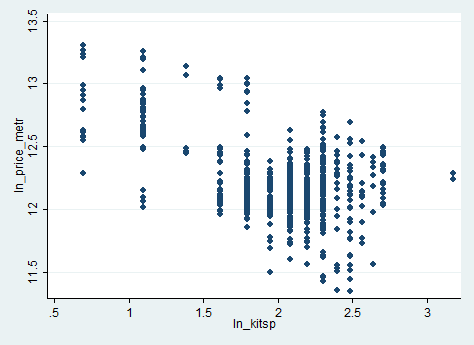

```stata
scatter ln_price_metr ln_livesp
```

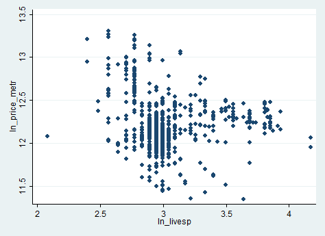

```stata
scatter ln_price_metr ln_dist
```

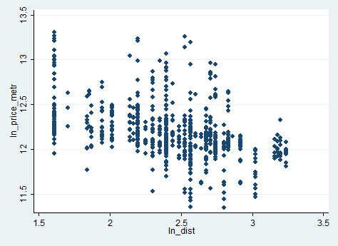

```stata
scatter ln_price_metr ln_metrdist
```

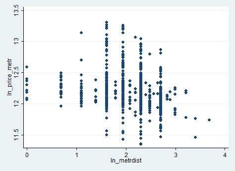

Подозрительны переменные `ln_kitsp` и `ln_metrdist` Проверим наличие гетероскедастичности с помощью тестов.

Тест Уайта строится по короткой команде:

```stata
estat imtest, white
```

```
running C:\Users\Yuliya\Documents\GitHub\bdemeshev\Econometrics-Rosetta-Stone\julia_work\pro
> file.do . estat imtest, white

White's test for Ho: homoskedasticity
         against Ha: unrestricted heteroskedasticity

         chi2(14)     =     89.02
         Prob > chi2  =    0.0000

Cameron & Trivedi's decomposition of IM-test

---------------------------------------------------
              Source |       chi2     df      p
---------------------+-----------------------------
  Heteroskedasticity |      89.02     14    0.0000
            Skewness |      41.02      4    0.0000
            Kurtosis |       3.10      1    0.0785
---------------------+-----------------------------
               Total |     133.14     19    0.0000
---------------------------------------------------
```

Тест Уайта выявил гетероскедастичность. Что скажет тест Бройша-Пагана?

```stata
estat hettest, rhs mtest
```

```
running C:\Users\Yuliya\Documents\GitHub\bdemeshev\Econometrics-Rosetta-Stone\julia_work\pro
> file.do . estat hettest, rhs mtest

Breusch-Pagan / Cook-Weisberg test for heteroskedasticity
         Ho: Constant variance

---------------------------------------
    Variable |      chi2   df      p
-------------+-------------------------
   ln_livesp |      0.00    1   0.9554 #
    ln_kitsp |      8.68    1   0.0032 #
     ln_dist |      1.43    1   0.2322 #
 ln_metrdist |      5.15    1   0.0233 #
-------------+-------------------------
simultaneous |     18.39    4   0.0010
---------------------------------------
                  # unadjusted p-values
```

И этот тест указывает на наличие нежелательной гетероскедастичности, особенно подозрительны переменные `ln_kitsp` и `ln_metrdist`.

Попробуем проверить ещё и через тест Голдфелда - Квандта. Сделаем его ручками.

Отсортируем наблюдения по возрастанию переменной `ln_kitsp`, построим регрессию и сохраним остатки.

```stata
sort ln_kitsp
reg ln_price_metr ln_livesp ln_kitsp ln_dist ln_metrdist in 1 / 258
scalar rss1 = e(rss)
```

```
running C:\Users\Yuliya\Documents\GitHub\bdemeshev\Econometrics-Rosetta-Stone\julia_work\pro
> file.do . sort ln_kitsp

      Source |       SS       df       MS              Number of obs =     258
-------------+------------------------------           F(  4,   253) =  101.40
       Model |  21.2645968     4   5.3161492           Prob > F      =  0.0000
    Residual |  13.2646645   253  .052429504           R-squared     =  0.6158
-------------+------------------------------           Adj R-squared =  0.6098
       Total |  34.5292613   257  .134355102           Root MSE      =  .22897

------------------------------------------------------------------------------
ln_price_~tr |      Coef.   Std. Err.      t    P>|t|     [95% Conf. Interval]
-------------+----------------------------------------------------------------
   ln_livesp |  -.2173122   .1051021    -2.07   0.040    -.4242986   -.0103257
    ln_kitsp |  -.6297139   .0524724   -12.00   0.000    -.7330522   -.5263756
     ln_dist |  -.3944732   .0447965    -8.81   0.000    -.4826947   -.3062517
 ln_metrdist |  -.0652324   .0289029    -2.26   0.025    -.1221534   -.0083114
       _cons |    15.0251   .2802776    53.61   0.000     14.47312    15.57707
------------------------------------------------------------------------------
```

Сохраним остатки и в последней части регрессии.

```stata
sort ln_kitsp
reg ln_price_metr ln_livesp ln_kitsp ln_dist ln_metrdist in 516 / 773
scalar rss2 = e(rss)
```

```
running C:\Users\Yuliya\Documents\GitHub\bdemeshev\Econometrics-Rosetta-Stone\julia_work\pro
> file.do . sort ln_kitsp

      Source |       SS       df       MS              Number of obs =     258
-------------+------------------------------           F(  4,   253) =   21.08
       Model |  5.10171614     4  1.27542903           Prob > F      =  0.0000
    Residual |  15.3095119   253  .060511905           R-squared     =  0.2499
-------------+------------------------------           Adj R-squared =  0.2381
       Total |  20.4112281   257  .079421121           Root MSE      =  .24599

------------------------------------------------------------------------------
ln_price_~tr |      Coef.   Std. Err.      t    P>|t|     [95% Conf. Interval]
-------------+----------------------------------------------------------------
   ln_livesp |  -.1140016   .0622764    -1.83   0.068    -.2366478    .0086446
    ln_kitsp |   .0358976   .0958643     0.37   0.708    -.1528962    .2246914
     ln_dist |  -.3344044   .0428089    -7.81   0.000    -.4187116   -.2500972
 ln_metrdist |  -.0757551   .0285959    -2.65   0.009    -.1320714   -.0194388
       _cons |   13.36548   .3551862    37.63   0.000     12.66598    14.06498
------------------------------------------------------------------------------
```

Посчитаем тестовую F-статистику.

```stata
scalar F = rss2 / rss1
display F
display invFtail(258, 258, 0.05)
```

```
running C:\Users\Yuliya\Documents\GitHub\bdemeshev\Econometrics-Rosetta-Stone\julia_work\pro
> file.do . scalar F = rss2 / rss1

1.1541575

1.2277536
```

Сейчас немного о способах борьбы с гетероскедастичностью. Подправим все коэффициенты исходной регрессии на гетероскедастичную переменную, например, на `ln_kitsp`.

```stata
gen ln_price_metr_new = ln_price_metr / ln_kitsp
gen ln_livesp_new = ln_livesp / ln_kitsp
gen const_new = 1 / ln_kitsp
gen ln_dist_new = ln_dist / ln_kitsp
gen ln_metrdist_new = ln_metrdist / ln_kitsp
```

```
running C:\Users\Yuliya\Documents\GitHub\bdemeshev\Econometrics-Rosetta-Stone\julia_work\pro
> file.do . gen ln_price_metr_new = ln_price_metr / ln_kitsp
```

И оценим регрессию с новыми переменными.

```stata
reg ln_price_metr_new ln_livesp_new const_new ln_dist_new ln_metrdist_new
```

```
running C:\Users\Yuliya\Documents\GitHub\bdemeshev\Econometrics-Rosetta-Stone\julia_work\pro
> file.do . reg ln_price_metr_new ln_livesp_new const_new ln_dist_new ln_metrdist_new

      Source |       SS       df       MS              Number of obs =     773
-------------+------------------------------           F(  4,   768) =60215.70
       Model |  4357.49806     4  1089.37451           Prob > F      =  0.0000
    Residual |  13.8940438   768  .018091203           R-squared     =  0.9968
-------------+------------------------------           Adj R-squared =  0.9968
       Total |   4371.3921   772    5.662425           Root MSE      =   .1345

---------------------------------------------------------------------------------
ln_price_metr~w |      Coef.   Std. Err.      t    P>|t|     [95% Conf. Interval]
----------------+----------------------------------------------------------------
  ln_livesp_new |  -.1844787   .0444441    -4.15   0.000     -.271725   -.0972323
      const_new |   14.53768   .1413858   102.82   0.000     14.26013    14.81523
    ln_dist_new |  -.3401237   .0254533   -13.36   0.000    -.3900899   -.2901574
ln_metrdist_new |  -.0738144   .0177665    -4.15   0.000     -.108691   -.0389377
          _cons |  -.4051279   .0213332   -18.99   0.000    -.4470063   -.3632495
---------------------------------------------------------------------------------
```

И полученные оценки будут эффективными оценками коэффициентов исходной регрессии.

Также можно использовать метод взвешенного МНК (WLS). Взвесим на стандартное отклонение фактора `ln_kitsp`.

```stata
vwls ln_price_metr ln_livesp ln_kitsp ln_dist ln_metrdist, sd(ln_kitsp)
```

```
running C:\Users\Yuliya\Documents\GitHub\bdemeshev\Econometrics-Rosetta-Stone\julia_work\pro
> file.do . vwls ln_price_metr ln_livesp ln_kitsp ln_dist ln_metrdist, sd(ln_kitsp)

Variance-weighted least-squares regression           Number of obs   =     773
Goodness-of-fit chi2(768)  =   13.89                 Model chi2(4)   =   23.60
Prob > chi2                =  1.0000                 Prob > chi2     =  0.0001
------------------------------------------------------------------------------
ln_price_~tr |      Coef.   Std. Err.      z    P>|z|     [95% Conf. Interval]
-------------+----------------------------------------------------------------
   ln_livesp |  -.1844788   .3304308    -0.56   0.577    -.8321113    .4631537
    ln_kitsp |  -.4051277   .1586073    -2.55   0.011    -.7159924   -.0942631
     ln_dist |  -.3401236   .1892387    -1.80   0.072    -.7110247    .0307775
 ln_metrdist |  -.0738144   .1320896    -0.56   0.576    -.3327052    .1850765
       _cons |   14.53768   1.051168    13.83   0.000     12.47743    16.59793
------------------------------------------------------------------------------
```

Способ #2. Используем робастные оценки Уайта.

```stata
reg ln_price_metr ln_livesp ln_kitsp ln_dist ln_metrdist, robust
```

```
running C:\Users\Yuliya\Documents\GitHub\bdemeshev\Econometrics-Rosetta-Stone\julia_work\pro
> file.do . reg ln_price_metr ln_livesp ln_kitsp ln_dist ln_metrdist, robust

Linear regression                                      Number of obs =     773
                                                       F(  4,   768) =  102.52
                                                       Prob > F      =  0.0000
                                                       R-squared     =  0.4179
                                                       Root MSE      =  .23089

------------------------------------------------------------------------------
             |               Robust
ln_price_~tr |      Coef.   Std. Err.      t    P>|t|     [95% Conf. Interval]
-------------+----------------------------------------------------------------
   ln_livesp |  -.1605276   .0409773    -3.92   0.000    -.2409685   -.0800867
    ln_kitsp |  -.2991296   .0284899   -10.50   0.000    -.3550568   -.2432023
     ln_dist |  -.3302511   .0240433   -13.74   0.000    -.3774495   -.2830527
 ln_metrdist |  -.0573754   .0145748    -3.94   0.000    -.0859867   -.0287642
       _cons |    14.1992   .1593064    89.13   0.000     13.88647    14.51192
------------------------------------------------------------------------------
```